# Visualisation Report

## WeRateDogs

WeRateDogs is a Twitter account that rates people's dogs with a humorous comment about the dog. The account was started in 2015 by college student Matt Nelson, and has received international media attention. As of December 2020, the Twitter account has nearly 9 million followers, and Nelson sees 30,000 likes on a post as being viral. His most popular post was of a dog marching in the 2017 Women's March, which was retweeted more than 50,000 times and favorited 134,000 times.

The account's language has spawned an Internet language about "doggos" and "puppers". A 2016 interaction with another Twitter user, when Nelson purposefully misnamed him "Brent" as is common in Weird Twitter, spawned the catchphrase "They're good dogs, Brent", which became one of the biggest memes of 2016.In 2017, the account was endorsed by J.K. Rowling.

WeRateDogs has successfully used the account to raise money for the American Society for the Prevention of Cruelty to Animals (ASPCA), as well as individual GoFundMe campaigns.

In October 2017, Nelson released a book based on the Twitter account, #WeRateDogs: The Most Hilarious and Adorable Pups You’ve Ever Seen.

I grabbed twitter data from the twitter handle of WeRateDogs from it's first tweet till AUG 2017. I compared and analysed a bunch of data and had the following observations with the help of some graphs.

## Visualising

### Retweets Count vs Favourite Tweet Count

I wanted to see the relation between retweets and favourites as it gives an insight on how people tend to react towards tweets about dogs and their cute behaviours.

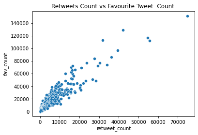

```python
sns.scatterplot(x=df['retweet_count'],y=df['fav_count'])
plt.title('Retweets Count vs Favourite Tweet  Count ');
```

#### Observations

By observing the scatter plot between the retweets count and favourite tweets count we can say that it shows a strong positive corelation. This seems obvious as when people favourite tweets they also tend to retweet the same and it also works the other way around, and there is no doubt people do love to retweet about dogs and favourite tweets about dogs because who doesn't love dogs.

### Tweet Source Comparison

I wanted to check how many people used different platforms to tweet about their dogs on WeRateDogs. So i compared the source url to test which one is the most used.

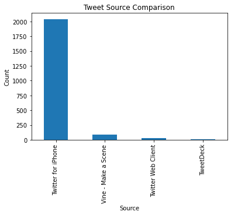

```python
df['source'].value_counts().plot(kind='bar')
plt.title('Tweet Source Comparison');
plt.xlabel('Source');
plt.ylabel('Count');
```

#### Observations

I was surprised to see such a huge difference between platforms used by twitter people as twitter for iPhones take the win with a huge margin, the other platforms don't even come close to it. But considering how phones are portable and it is easier to share pictures and videos through it ,it makes a lot of sense. Comparing Vine and twitter web during 2015-17, vine was a big deal and it seems perfectly resonable to see it above the web client.

### Most Popular Dog Breeds

One of the first things I was interested in knowing is: what are the most common dog breeds that appear in the tweets made by WeRateDogs? Since the cleaned dataset already contains the correct predictions made by the algorithm.

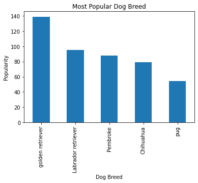

```python
df['p1'].value_counts().head(5).plot(kind='bar')
plt.title('Most Popular Dog Breed');
plt.xlabel('Dog Breed');
plt.ylabel('Popularity');
```

#### Observations

Here I can see that the dog breed that appears most often in WeRateDogs tweets even compared to the rest of the most common dog breeds is the Golden Retriever. In fact, it seems that the Golden Retriever is far and away the most common dog breed. Given the WeRateDogs account's huge following, this could be an indication of the overall popularity of not only the breeds shown in the chart but the other breeds in the sample as well.

### Most Common Dog Stage

One of the more interesting and unique aspects of WeRateDogs is the lingo that has developed around the account. Dogs are called 'pupper', 'puppo', or 'doggo' based on how old their dog is with 'pupper' being used for puppies, 'doggo' for adult dogs, and 'puppo' for dogs in a stage of development between puppy and adult. There is also the word 'floofer' which is used to describe dogs with fur.

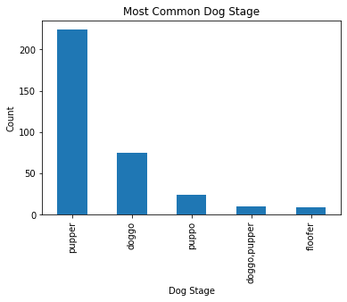

```python
df['stage'].value_counts().head(5).plot(kind='bar')
plt.title('Most Common Dog Stage');
plt.xlabel('Dog Stage');
plt.ylabel('Count');
```

#### Observations

As I can see the maximum number of dogs rated on WeRateDogs are puppers. Although i didn't calculate the whole data as this was the only information available and can be seen by the count. But seeing a large number of tweets about puppers is also reasonable as they tend to do silly and cute stuff nonetheless some dogs never grow up.

## Conclusion

I've described a handful of insights that can be gained from the WeRateDogs twitter archive. There are still many more stuff which can be analysed. I hope that this article has shown you that, while there's a lot that goes into extracting meaning full information, but nothing is impossible, all you have to do is gather some data and start working your way around it.